# TidyTuesday 2019 week 26 Global UFO sightings

```r
library(tidyverse)
library(lubridate)
library(magrittr)
library(pheatmap)
```

> This script creates a heatmap of the number of UFO sightings in the UK for each day of the week

```r
purrr::walk(c(
  "https://www.tidyverse.org/packages",
  "https://dplyr.tidyverse.org/reference/index.html",
  "https://tidyr.tidyverse.org/reference/index.html",
  #"https://purrr.tidyverse.org/reference/index.html"
  #"https://jennybc.github.io/purrr-tutorial/ls13_list-columns.html",
  #"https://tibble.tidyverse.org/reference/index.html",
  #"https://readr.tidyverse.org/reference/index.html",
  #"https://stringr.tidyverse.org/reference/index.html",
  "https://forcats.tidyverse.org/reference/index.html",
  "https://lubridate.tidyverse.org/reference/index.html"
  #"https://ggplot2.tidyverse.org/reference/index.html",
  #"https://readxl.tidyverse.org/reference/index.html",
  #"https://db.rstudio.com"
),
browseURL)
```

```r
ufo_sightings_raw <- readr::read_csv("https://raw.githubusercontent.com/rfordatascience/tidytuesday/master/data/2019/2019-06-25/ufo_sightings.csv")
```

First of all I am only interested in UFO sightings in the UK. Filtering on the city_area field produces more sightings than using the country field

```r
ufo_sightings_uk <- ufo_sightings_raw %>%
  filter(str_detect(city_area, "uk/"))
```

This leaves us with 2,354 sightings. I am interested in counting the number of hourly sightings for each day, across all years so need to use the date_time column to extract days and hour columns.

I couldn’t find a quick way of converting the hours to 12 hour labels and resorted to using lubridate’s am and pm functions, addeing the midnight and midday labels afterwards.

Note I also set the start of the week as Monday rather than Sunday so that Sunday occurs at the end of the week.

```r
ufo_sightings_uk_counts <- ufo_sightings_uk %>%
  transmute(date_time = parse_date_time(date_time, "mdy HM")) %>%
  mutate(hour = case_when(
     am(date_time) ~ str_glue("{hour(date_time)} am"),
     pm(date_time) ~ str_glue("{hour(date_time) -12} pm"),
     TRUE ~ NA_character_
  )) %>%
  mutate(hour = as.character(hour)) %>%
  mutate(hour = case_when(
     hour == "0 am" ~ "midnight",
     hour == "0 pm" ~ "midday",
     TRUE ~ hour
  )) %>%
  mutate(weekday = wday(date_time, label = TRUE,
                        week_start = 1)) %>% # set Monday as the start of the week
  select(-date_time)
```

Now to count the number of UFO sightings per hour for each weekday and spread dataset by weekdays

```r
ufo_sightings_uk_counts <- ufo_sightings_uk_counts %>%
  group_by_all() %>%
  tally(name = "ufo_sightings") %>%
  ungroup()
ufo_sightings_uk_counts <- ufo_sightings_uk_counts %>%
  spread(weekday, ufo_sightings, fill = 0L) %T>%
  glimpse()
```

```
Observations: 24
Variables: 8
$ hour <chr> "1 am", "1 pm", "10 am", "10 pm", "11 am", "11 pm", "2 am", "2 pm", "3 am...
$ Mon  <int> 16, 6, 6, 46, 9, 28, 13, 5, 8, 8, 5, 9, 2, 4, 3, 18, 2, 15, 2, 25, 3, 28,...
$ Tue  <int> 10, 4, 1, 41, 7, 35, 9, 3, 7, 6, 4, 10, 4, 13, 4, 16, 2, 19, 1, 23, 0, 27...
$ Wed  <int> 10, 0, 1, 44, 3, 39, 8, 5, 8, 5, 6, 7, 2, 10, 1, 17, 3, 15, 5, 28, 3, 32,...
$ Thu  <int> 13, 6, 3, 42, 6, 35, 8, 4, 7, 9, 4, 7, 4, 12, 8, 14, 7, 35, 2, 16, 2, 38,...
$ Fri  <int> 15, 9, 3, 45, 4, 46, 11, 4, 7, 10, 3, 6, 3, 15, 4, 17, 3, 23, 3, 29, 5, 3...
$ Sat  <int> 21, 7, 0, 80, 5, 63, 10, 6, 9, 6, 7, 6, 2, 11, 4, 14, 3, 38, 3, 40, 3, 60...
$ Sun  <int> 13, 10, 8, 39, 8, 38, 16, 9, 13, 11, 7, 20, 4, 13, 5, 29, 8, 39, 1, 26, 4...
```

The data frame is now in the format needed to produce a heatmap, apart from the ordering of the hours is not what I would like

To order the row going upwards from 1am to midnight I converted the hour column to an orderd factor giving the required order. To make midnight the first row I then had to reverse the order!

```r
hour_order <- c("1 am", "2 am", "3 am", "4 am", "5 am", "6 am", "7 am", "8 am",
                "9 am", "10 am", "11 am", "midday",
                "1 pm", "2 pm", "3 pm", "4 pm", "5 pm", "6 pm", "7 pm", "8 pm",
                "9 pm", "10 pm", "11 pm", "midnight")
ufo_sightings_uk_counts <- ufo_sightings_uk_counts %>%
  mutate(hour = factor(hour, levels = hour_order)) %>%
  mutate(hour = fct_rev(hour)) %>%
  arrange(hour)
```

Now to create the heatmap

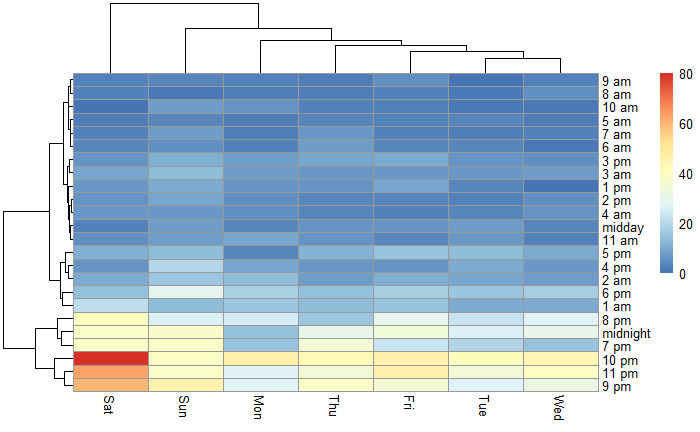

```r
ufo_matrix <- data.matrix(ufo_sightings_uk_counts)[, -1]
rownames(ufo_matrix) <- ufo_sightings_uk_counts$hour
pheatmap(ufo_matrix )
```